# Biostat M280 Homework 3

Due Mar 2 @ 11:59PM

## Q1 LA City Employee Payroll

The `/home/m280-data/la_payroll/LA_City_Employee_Payroll.csv` file on teaching server contains payroll information of LA City employees in years 2013-2017. It was downloaded from [LA City Controller’s Office](https://controllerdata.lacity.org/Payroll/City-Employee-Payroll/pazn-qyym). Make a Shiny app to facilitate exploratory data analysis.

1. For efficiency of the Shiny app, you should first pre-process, pare down, tidy, and save the data, e.g., as a compressed RDS file, to be used in the app.

   I pre-process, pare down, tidy, and save the data as a compressed RDS file.

   ```r
   LA <- read_csv("/home/m280-data/la_payroll/LA_City_Employee_Payroll.csv")
   saveRDS(LA, "payroll_origin.rds", compress = TRUE)
   payroll_origin <- read_rds("payroll_origin.rds")

   payroll_origin$totalpayments <-
   as.numeric(gsub("\\$", "", payroll_origin$"Total Payments"))
   payroll_origin$basepay <-
   as.numeric(gsub("\\$", "", payroll_origin$"Base Pay"))
   payroll_origin$overtimepay <-
   as.numeric(gsub("\\$", "", payroll_origin$"Overtime Pay"))
   payroll_origin$otherpay <-
   as.numeric(gsub("\\$", "", payroll_origin$"Other Pay (Payroll Explorer)"))
   payroll_origin$cost <-
   as.numeric(gsub("\\$", "", payroll_origin$"Average Benefit Cost"))
   payroll_origin$bonus <-
   as.numeric(gsub("\\$", "", payroll_origin$"Permanent Bonus Pay"))
   head(payroll_origin)
   ```

   ```
   ## # A tibble: 6 x 41
   ##   `Row ID`       Year `Department Titl… `Payroll Departme… `Record Number`
   ##   <chr>         <int> <chr>                          <int>           <int>
   ## 1 3-1000027830…  2013 Police (LAPD)                   4301      1000027830
   ## 2 3-1000155488…  2013 Police (LAPD)                   4302      1000155488
   ## 3 3-1000194958…  2013 Police (LAPD)                   4301      1000194958
   ## 4 3-1000198958…  2013 Zoo                             8701      1000198958
   ## 5 3-1000232317…  2013 Police (LAPD)                   4301      1000232317
   ## 6 3-1000329284…  2013 Police (LAPD)                   4302      1000329284
   ## # ... with 36 more variables: `Job Class Title` <chr>, `Employment
   ## #   Type` <chr>, `Hourly or Event Rate` <chr>, `Projected Annual
   ## #   Salary` <chr>, `Q1 Payments` <chr>, `Q2 Payments` <chr>, `Q3
   ## #   Payments` <chr>, `Q4 Payments` <chr>, `Payments Over Base Pay` <chr>,
   ## #   `% Over Base Pay` <chr>, `Total Payments` <chr>, `Base Pay` <chr>,
   ## #   `Permanent Bonus Pay` <chr>, `Longevity Bonus Pay` <chr>, `Temporary
   ## #   Bonus Pay` <chr>, `Lump Sum Pay` <chr>, `Overtime Pay` <chr>, `Other
   ## #   Pay & Adjustments` <chr>, `Other Pay (Payroll Explorer)` <chr>,
   ## #   MOU <int>, `MOU Title` <chr>, `FMS Department` <int>, `Job
   ## #   Class` <int>, `Pay Grade` <chr>, `Average Health Cost` <chr>, `Average
   ## #   Dental Cost` <chr>, `Average Basic Life` <chr>, `Average Benefit
   ## #   Cost` <chr>, `Benefits Plan` <chr>, `Job Class Link` <chr>,
   ## #   totalpayments <dbl>, basepay <dbl>, overtimepay <dbl>, otherpay <dbl>,
   ## #   cost <dbl>, bonus <dbl>
   ```

2. **Total payroll by LA City**. Visualize the total LA City payroll of each year, with breakdown into base pay, overtime pay, and other pay.
3. **Who earned most?** Visualize the payroll information (total payment with breakdown into base pay, overtime pay, and other pay, Department, Job Title) of the top $n$ highest paid LA City employees in a specific year. User specifies $n$ (default 10) and year (default 2017).
4. **Which departments earn most?** Visualize the mean or median payroll, with breakdown into base pay, overtime pay, and other pay, of top $n$ earning departments. User specifies $n$ (default 5), year (default 2017), and method (mean or median, default median).
5. **Which departments cost most?** Visualize the total payroll, with breakdown into base pay, overtime pay, and other pay, of top $n$ expensive departments. User specifies $n$ (default 5) and year (default 2017).
6. Visualize any other information you are interested in.
7. Publish your Shiny app to https://www.shinyapps.io and share the link.

*This is the link to my shiny app, https://nullnullnu.shinyapps.io/shiny/.*

## Q2 LA City Parking War

The SQLite database `/home/m280-data/la_parking/LA_Parking_Citations.sqlite` on teaching server contains information about parking tickets in LA City. It was downloaded from [LA Open Data Portal](https://data.lacity.org/A-Well-Run-City/Parking-Citations/wjz9-h9np). Connect to the database and answer following questions using plots and summary statistics. In this exercise, you are **not** allowed to load whole data into memory. Use the *transform in database, plot in R* strategy.

````
```r
parking <- dbConnect(RSQLite::SQLite(),
  dbname = "/home/m280-data/la_parking/LA_Parking_Citations_Extra.sqlite")
dbListTables(parking)
```

```
## [1] "latix"
```

```r
latix_sql <- dplyr::tbl(parking, "latix")
```
````

1. How many tickets are in this data set? Which time period do these tickets span? Which years have most data?

   There are 4044338 tickets in the data set.

   ```sql
   SELECT COUNT(DISTINCT Ticket_number) FROM latix
   ```

   1 records

   | COUNT(DISTINCT Ticket_number) |
   | --- |
   | 4044338 |

   The time period of these tickets is from 2010/04/27 21:40 to 2017/12/30 01:41.

   ```sql
   SELECT
   MAX(Issue_Year || '/' || SUBSTR('0' || Issue_Month, -2 )
   || '/' || SUBSTR('0' || Issue_Day, -2) || ' '
   || SUBSTR('0' || Issue_Hour, -2) || ':'
   || SUBSTR('0' || Issue_Minute, -2)) as 'Max',
   MIN(Issue_Year || '/' || SUBSTR('0' || Issue_Month, -2 )
   || '/' || SUBSTR('0' || Issue_Day, -2) || ' '
   || SUBSTR('0' || Issue_Hour, -2) || ':'
   || SUBSTR('0' || Issue_Minute, -2)) as 'Min'
   FROM latix
   ```

   1 records

   | Max | Min |
   | --- | --- |
   | 2017/12/30 01:41 | 2010/04/27 21:40 |

   The year 2015 has the most data.

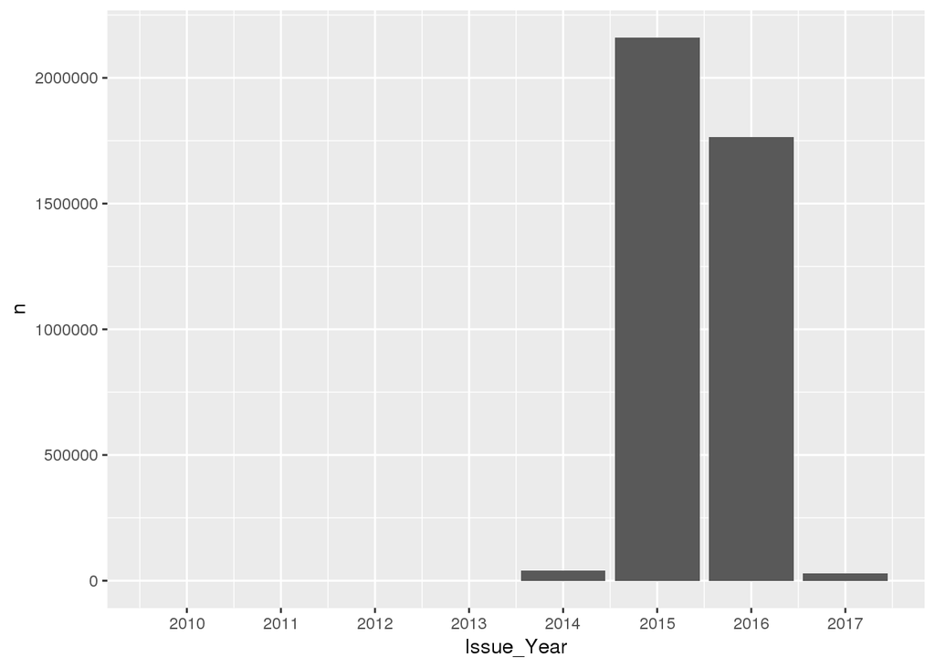

   ```r
   latix_sql %>%
     filter(!is.na(Issue_Year)) %>%
     group_by(Issue_Year) %>%
     count() %>%
     collect() %>%
     ggplot(latix_sql, mapping = aes(x = Issue_Year, y = n)) +
     scale_x_continuous(breaks = c(2010:2017)) +
     geom_col()
   ```

2. When (which hour, weekday, month day, and month) are you most likely to get a ticket and when are you least likely to get a ticket?

   You are most likely to get a ticket at hour 12. You are least likely to get a ticket at hour 5.

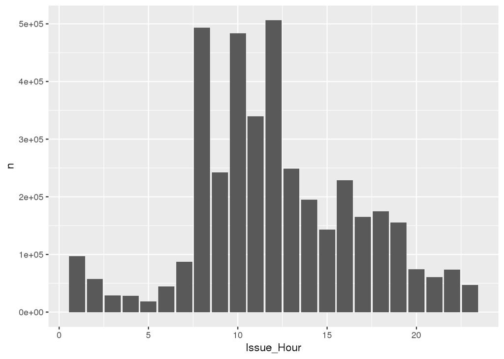

   ```r
   latix_sql %>%
     filter(!is.na(Issue_Hour)) %>%
     group_by(Issue_Hour) %>%
     count() %>%
     collect() %>%
     ggplot(latix_sql, mapping = aes(x = Issue_Hour, y = n)) +
         geom_col()
   ```

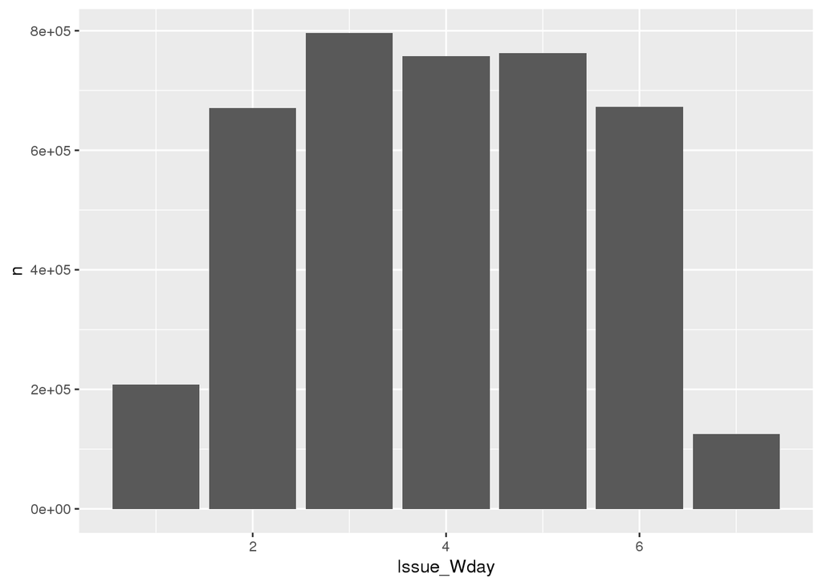

   ```r
   latix_sql %>%
     filter(!is.na(Issue_Wday)) %>%
     group_by(Issue_Wday) %>%
     count() %>%
     collect() %>%
     ggplot(latix_sql, mapping = aes(x = Issue_Wday, y = n)) +
         geom_col()
   ```

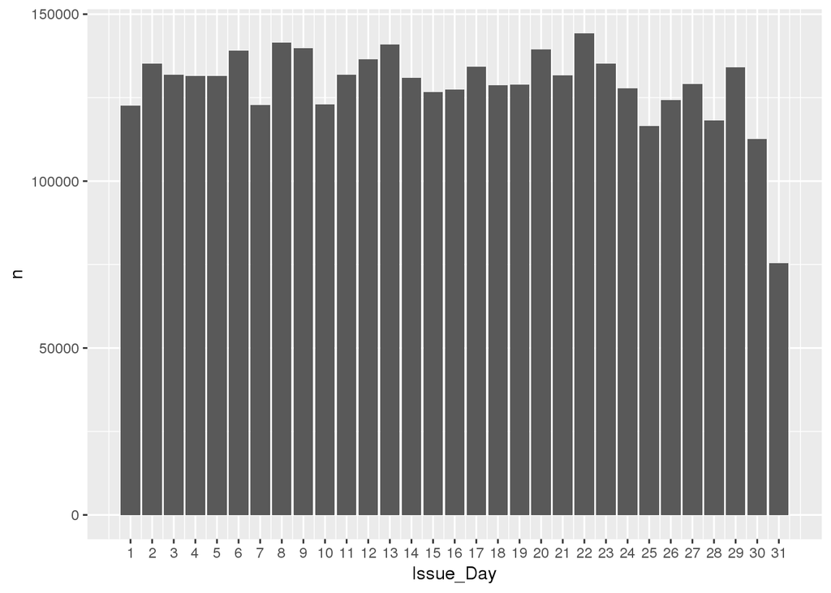

   ```r
   latix_sql %>%
     filter(!is.na(Issue_Day)) %>%
     group_by(Issue_Day) %>%
     count() %>%
     collect() %>%
     ggplot(latix_sql, mapping = aes(x = Issue_Day, y = n)) +
     scale_x_continuous(breaks = c(1:31)) +
         geom_col()
   ```

   You are most likely to get a ticket at March. You are least likely to get a ticket at November.

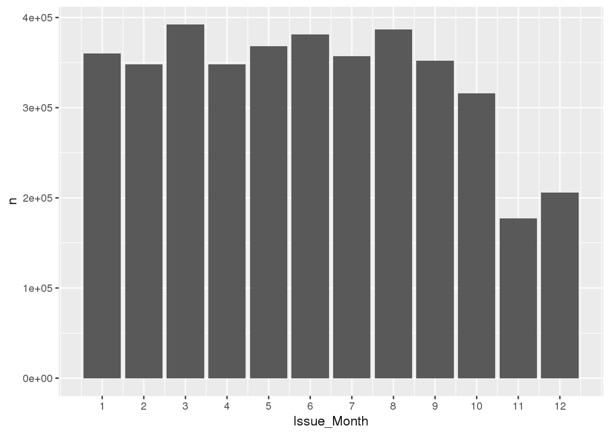

   ```r
   latix_sql %>%
     filter(!is.na(Issue_Month)) %>%
     group_by(Issue_Month) %>%
     count() %>%
     collect() %>%
     ggplot(latix_sql, mapping = aes(x = Issue_Month, y = n)) +
     scale_x_continuous(breaks = c(1:12)) +
         geom_col()
   ```

3. Which car makes received most citations?

   The toyota received most citations.

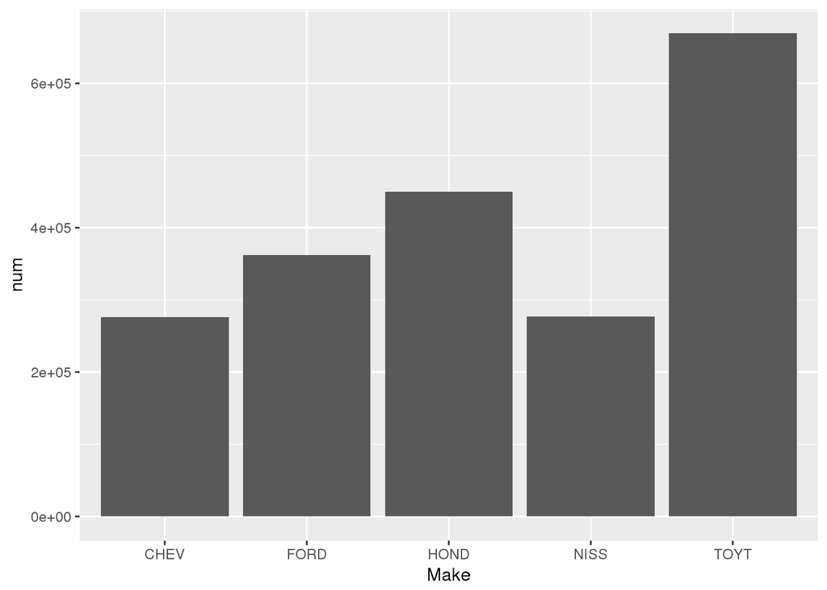

   ```r
   latix_sql %>%
     filter(!is.na(Make)) %>%
     group_by(Make) %>%
     summarise(num = n()) %>%
     collect() %>%
     top_n(5) %>%
     ggplot(latix_sql, mapping = aes(x = Make, y = num)) +
         geom_col()
   ```

4. How many different colors of cars were ticketed? Which color attracted most tickets?

   There are 65 different colors of cars were ticketed.

   ```sql
   SELECT COUNT(DISTINCT Color) FROM latix
   ```

   1 records

   | COUNT(DISTINCT Color) |
   | --- |
   | 65 |

   The color black attracked most tickets.

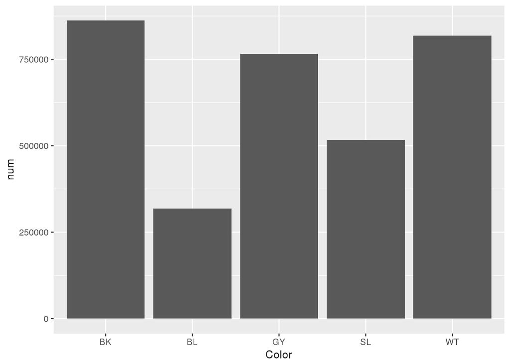

   ```r
   latix_sql %>%
     filter(!is.na(Color)) %>%
     group_by(Color) %>%
     summarise(num = n()) %>%
     collect() %>%
     top_n(5) %>%
     ggplot(latix_sql, mapping = aes(x = Color, y = num)) +
         geom_col()
   ```

5. What are the most common ticket types?

   NO PARK/STREET CLEAN, METER EXP, and PREFERENTIAL PARKING are the most common ticket types.

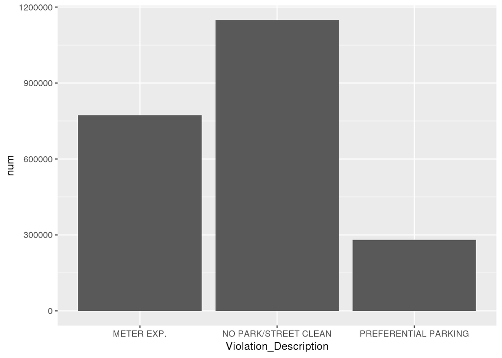

   ```r
   latix_sql %>%
     filter(!is.na(Violation_Description)) %>%
     group_by(Violation_Description) %>%
     summarise(num = n()) %>%
     collect() %>%
     top_n(3) %>%
     ggplot(latix_sql, mapping = aes(x = Violation_Description, y = num)) +
         geom_col()
   ```

6. How much money was collected on parking tickets in 2015 and 2016?

   151006794 dollors were collected on parking tickets in 2015. 123236136 dollors were collected for 2016.

   ```sql
   SELECT
   Issue_Year, SUM(Fine_amount)
   FROM latix
   GROUP BY Issue_Year
   ORDER BY SUM(Fine_amount) DESC
   ```

   9 records

   | Issue_Year | SUM(Fine_amount) |
   | --- | --- |
   | 2015 | 151006794 |
   | 2016 | 123236136 |
   | NA | 3520929 |
   | 2014 | 2715234 |
   | 2017 | 2113325 |
   | 2013 | 2939 |
   | 2012 | 1695 |
   | 2011 | 919 |
   | 2010 | 255 |

7. Visualize any other information you are interested in.

   I am interested in which states of the plate attracted most tickets. It seems that California plates got the most tickets.

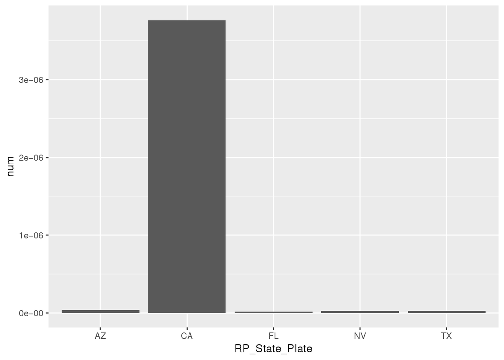

   ```r
   latix_sql %>%
     filter(!is.na(RP_State_Plate)) %>%
     group_by(RP_State_Plate) %>%
     summarise(num = n()) %>%
     collect() %>%
     top_n(5) %>%
     ggplot(latix_sql, mapping = aes(x = RP_State_Plate, y = num)) +
         geom_col()
   ```

   ```r
   dbDisconnect(parking)
   ```